# Practical ML

# Introduction

In this project we build a prediction model fot how well a weight lifting exercise is executed. To this end, we use the data available at http://groupware.les.inf.puc-rio.br/har (see the section on the Weight Lifting Exercise Dataset). The dataset contains samples of executed exercises from a group of 5 people, who were requested to perform the exercise in 5 different ways: one was the correct one, and the other four corresponded to performing the exercise with one of the most frequent errors.

## Data

For our project, we use the following datasets:

- Training set [https://d396qusza40orc.cloudfront.net/predmachlearn/pml-training.csv]
- Test set [https://d396qusza40orc.cloudfront.net/predmachlearn/pml-testing.csv]

The data are loaded as follows into R.

```r
train <- read.csv('pml-training.csv', na.strings=c("NA","#DIV/0!", ""))
test <- read.csv('pml-testing.csv', na.strings=c("NA","#DIV/0!", ""))
```

A quick glance at the data in the training set makes it evident that there are a bunch of variables which are just NAs, we thus delete them.

```r
 columns_to_select <- colSums(is.na(train)) == 0
train <- train[,columns_to_select]
test <- test[, columns_to_select]

train <- train[,-c(1:7)]
test <- test[, -c(1:7)]
```

## Explanation of the analysis

There are five different types of execution for the exercise: the correct one (classe A), and four incorrect ones, corresponding to four different errors in the execution (classe B, C, D, E). We tackle the problem with two possible approaches: random forest and decision tree.

### Cross Validation

To pick the best prediction model we will make use of cross validation. To this end, we split the training set randomly and without replacements into a training set, on which the model is fitted, and a test set, on which we will make the choice of the best model. The code for this splitting is as follows.

```r
library(caret)
```

```r
library(ggplot2)
library(rpart)
library(rpart.plot)
library(randomForest)
trainIN <- createDataPartition(y=train$classe, p=0.7, list=FALSE)
train_training <- train[trainIN,]
train_testing <- train[-trainIN,]
```

### Model 1: Decision Tree

The first model is a decision tree.

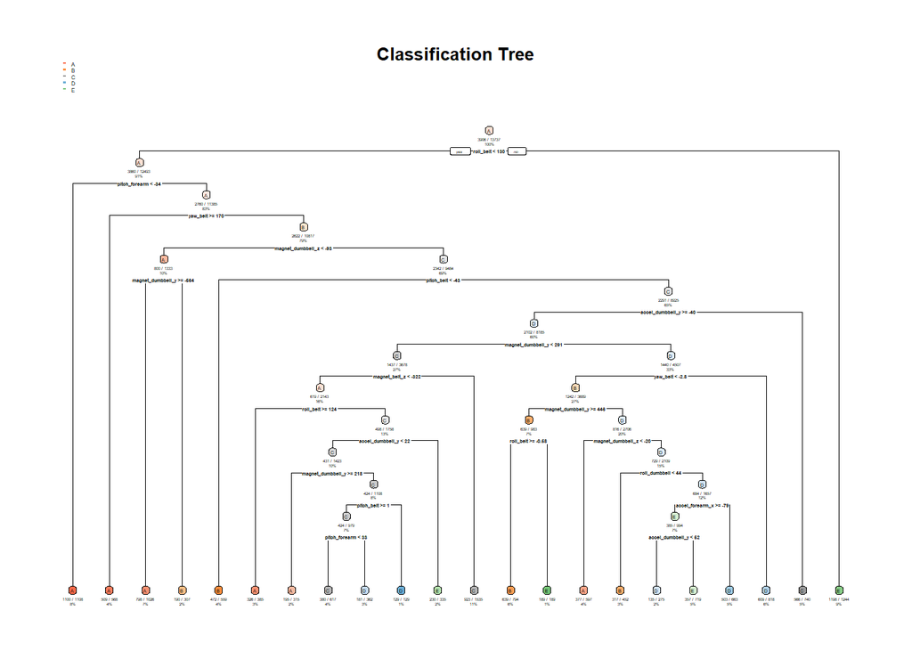

```r
m1 <- rpart(classe ~ ., data=train_training, method="class")

prediction1 <- predict(m1, train_testing, type = "class")

rpart.plot(m1, main="Classification Tree", extra=102, under=TRUE, faclen=0)
```

Let us look at the confusion matrix on the test part of the training set.

```r
confusionMatrix(prediction1, factor(train_testing$classe))
```

```
## Confusion Matrix and Statistics
##
##           Reference
## Prediction    A    B    C    D    E
##          A 1372  196   15   60   50
##          B   52  700   72   59   55
##          C   82  124  766  130   89
##          D  109   68   74  684   74
##          E   59   51   99   31  814
##
## Overall Statistics
##
##                Accuracy : 0.7368
##                  95% CI : (0.7253, 0.748)
##     No Information Rate : 0.2845
##     P-Value [Acc > NIR] : < 2.2e-16
##
##                   Kappa : 0.6673
##
##  Mcnemar's Test P-Value : < 2.2e-16
##
## Statistics by Class:
##
##                      Class: A Class: B Class: C Class: D Class: E
## Sensitivity            0.8196   0.6146   0.7466   0.7095   0.7523
## Specificity            0.9238   0.9499   0.9125   0.9340   0.9500
## Pos Pred Value         0.8104   0.7463   0.6432   0.6779   0.7723
## Neg Pred Value         0.9280   0.9113   0.9446   0.9426   0.9445
## Prevalence             0.2845   0.1935   0.1743   0.1638   0.1839
## Detection Rate         0.2331   0.1189   0.1302   0.1162   0.1383
## Detection Prevalence   0.2877   0.1594   0.2024   0.1715   0.1791
## Balanced Accuracy      0.8717   0.7822   0.8296   0.8218   0.8512
```

## Model 2: Random Forest

The second model is a random forest.

```r
train_training$classe <- factor(train_training$classe)
m2 <- randomForest(classe ~. , data=train_training, method="class")

prediction2 <- predict(m2, train_testing, type = "class")

confusionMatrix(prediction2, factor(train_testing$classe))
```

```
## Confusion Matrix and Statistics
##
##           Reference
## Prediction    A    B    C    D    E
##          A 1673    5    0    0    0
##          B    1 1134    6    0    0
##          C    0    0 1018   11    1
##          D    0    0    2  952    2
##          E    0    0    0    1 1079
##
## Overall Statistics
##
##                Accuracy : 0.9951
##                  95% CI : (0.9929, 0.9967)
##     No Information Rate : 0.2845
##     P-Value [Acc > NIR] : < 2.2e-16
##
##                   Kappa : 0.9938
##
##  Mcnemar's Test P-Value : NA
##
## Statistics by Class:
##
##                      Class: A Class: B Class: C Class: D Class: E
## Sensitivity            0.9994   0.9956   0.9922   0.9876   0.9972
## Specificity            0.9988   0.9985   0.9975   0.9992   0.9998
## Pos Pred Value         0.9970   0.9939   0.9883   0.9958   0.9991
## Neg Pred Value         0.9998   0.9989   0.9984   0.9976   0.9994
## Prevalence             0.2845   0.1935   0.1743   0.1638   0.1839
## Detection Rate         0.2843   0.1927   0.1730   0.1618   0.1833
## Detection Prevalence   0.2851   0.1939   0.1750   0.1624   0.1835
## Balanced Accuracy      0.9991   0.9971   0.9949   0.9934   0.9985
```

## Model selection

Based on the accuracy of the two models tested on the validation set, we pick the random forest model.

## Final submission

Using the random forest model we obtain the following prediction.

```r
predictfinal <- predict(m2, test, type="class")
predictfinal
```

```
##  1  2  3  4  5  6  7  8  9 10 11 12 13 14 15 16 17 18 19 20
##  B  A  B  A  A  E  D  B  A  A  B  C  B  A  E  E  A  B  B  B
## Levels: A B C D E
```